# Validation project

## Графики базовых характеристик

```r
# Удаляем повторы для проведения анализа


data_final %>%
  distinct(id, .keep_all = TRUE) -> df_basic
```

Продолжительность госпитализации

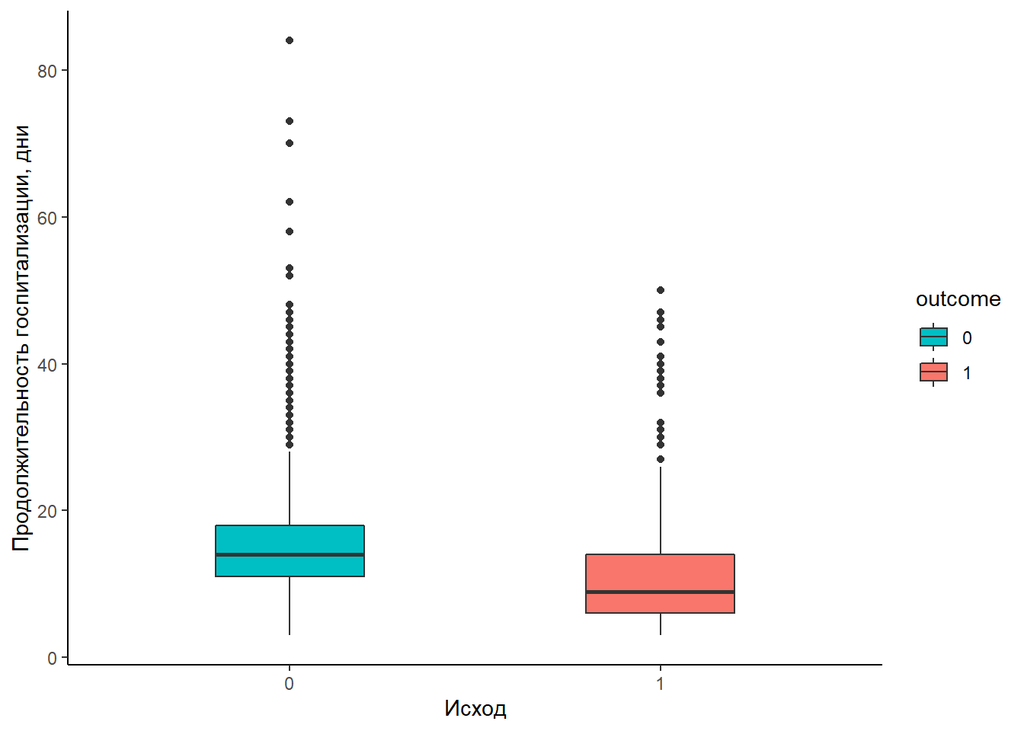

```r
ggplot(df_basic, aes(y = hospitalization,
                     x = outcome)) +
  geom_boxplot(width = 0.4, aes(fill = outcome)) +
  scale_fill_manual(values = c("#00BFC4", "#F8766B"))+
  theme_classic() +
  ylab("Продолжительность госпитализации, дни") +
  xlab("Исход")
```

Возраст умерших (1) и выписавшихся (0) пациентов

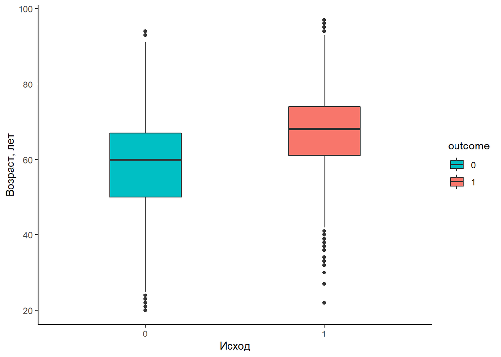

```r
ggplot(df_basic, aes(y = age,
                     x = outcome,
                     fill = outcome)) +
  geom_boxplot(width = 0.4) +
  scale_fill_manual(values = c("#00BFC4", "#F8766B")) +
  theme_classic() +
  ylab("Возраст, лет") +
  xlab("Исход")
```

Гистограмма с датами поступления умерших и выписавшихся пациентов

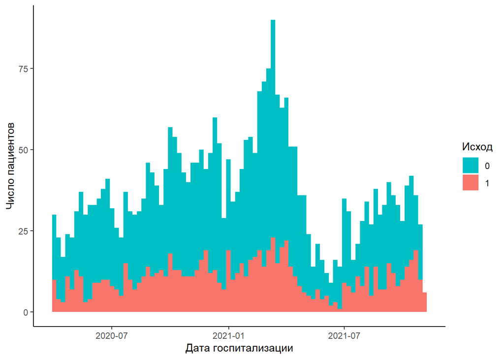

```r
ggplot(df_basic, aes(x = StartDate, fill = outcome)) +
    geom_histogram(binwidth = 7) +
    scale_fill_manual(values = c("#00BFC4", "#F8766B"))+
    theme_classic() +
    xlab("Дата госпитализации")+
    ylab("Число пациентов")+
    labs(fill = "Исход")
```

```r
summary(df_basic$StartDate)
```

```
##         Min.      1st Qu.       Median         Mean      3rd Qu.         Max.
## "2020-03-30" "2020-09-18" "2021-01-17" "2021-01-12" "2021-04-16" "2021-11-05"
```

```r
summary(df_basic$OutcomeDate)
```

```
##         Min.      1st Qu.       Median         Mean      3rd Qu.         Max.
## "2020-04-04" "2020-10-01" "2021-02-01" "2021-01-26" "2021-04-29" "2021-11-12"
```

# Валидация шкалы

Создаём отдельный датафрейм с 9 интересующими нас параметрами.

```r
# Т.к. эти фрагменты работ выполнялись разными авторами параллельно,
# имена столбцов были изменены чтобы код сохранил работоспособность.

score_9 <- data_final %>%
    select(id,
           Outcome = outcome,
           DaysBfOutcome,
           DayOfHosp = hospitalization,
           AnalysisDate = date,
           `d-dimer` = `D_dimer`,
           urea = Urea,
           limphocite_perc = Lymphocytes,
           crp = CRP,
           protein_total = Total_protein,
           aptt = APTT,
           wbc = WBC,
           hg = Hemoglobin,
           glucose = Glucose) %>%
    ungroup() %>%
    mutate(DayOfHosp = as.numeric(DayOfHosp),
           DaysBfOutcome = as.numeric(DaysBfOutcome),
           limphocite_perc = limphocite_perc / 100 * wbc)

score_9 %>% summary()
```

```
##        id        Outcome   DaysBfOutcome      DayOfHosp
##  1048458:   21   0:11436   Min.   : 0.000   Min.   : 3.00
##  1051937:   21   1: 6763   1st Qu.: 4.000   1st Qu.:11.00
##  1067516:   21             Median : 8.000   Median :15.00
##  1103765:   21             Mean   : 8.395   Mean   :16.07
##  1130251:   21             3rd Qu.:12.000   3rd Qu.:20.00
##  1067222:   20             Max.   :20.000   Max.   :84.00
##  (Other):18074
##   AnalysisDate           d-dimer           urea         limphocite_perc
##  Min.   :2020-03-30   Min.   :    0   Min.   :  0.360   Min.   : 0.00
##  1st Qu.:2020-10-15   1st Qu.:  590   1st Qu.:  5.660   1st Qu.: 0.62
##  Median :2021-02-25   Median : 1500   Median :  7.800   Median : 1.02
##  Mean   :2021-02-14   Mean   : 2978   Mean   :  9.963   Mean   : 1.26
##  3rd Qu.:2021-07-02   3rd Qu.: 4310   3rd Qu.: 11.300   3rd Qu.: 1.61
##  Max.   :2021-11-11   Max.   :41700   Max.   :134.000   Max.   :98.40
##                       NA's   :4295    NA's   :348       NA's   :923
##       crp        protein_total         aptt             wbc
##  Min.   :  0.1   Min.   : 29.00   Min.   :  1.00   Min.   :  0.00
##  1st Qu.: 12.0   1st Qu.: 52.00   1st Qu.: 26.00   1st Qu.:  6.77
##  Median : 36.0   Median : 58.00   Median : 32.00   Median :  9.60
##  Mean   : 58.7   Mean   : 58.05   Mean   : 38.05   Mean   : 11.13
##  3rd Qu.: 89.4   3rd Qu.: 63.00   3rd Qu.: 41.50   3rd Qu.: 13.60
##  Max.   :438.6   Max.   :709.00   Max.   :523.00   Max.   :240.00
##  NA's   :1370    NA's   :2223     NA's   :1242     NA's   :290
##        hg            glucose
##  Min.   :   0.0   Min.   :  0.100
##  1st Qu.: 106.0   1st Qu.:  5.790
##  Median : 121.0   Median :  7.800
##  Mean   : 119.9   Mean   :  9.187
##  3rd Qu.: 134.0   3rd Qu.: 11.200
##  Max.   :1568.0   Max.   :189.100
##  NA's   :300      NA's   :282
```

Рассчитываем score (значения шкалы) по способу, описанному в статье

```r
score_9 <- score_9 %>%
    mutate(score = if_else(score_9$'d-dimer' > 2149 & !is.na(score_9$'d-dimer'), 4, 0) +
                   if_else(score_9$urea > 11 & !is.na(score_9$urea), 5, 0) +
                   if_else(score_9$limphocite_perc < 0.7 & !is.na(score_9$limphocite_perc), 3, 0) +
                   if_else(score_9$crp > 146 & !is.na(score_9$crp), 3, 0) +
                   if_else(score_9$protein_total < 61 & !is.na(score_9$protein_total), 6, 0) +
                   if_else(score_9$aptt > 42 & !is.na(score_9$aptt), 4, 0) +
                   if_else(score_9$wbc > 13.5 & !is.na(score_9$wbc), 4, 0) +
                   if_else(score_9$hg < 115 & !is.na(score_9$hg), 3, 0) +
                   if_else(score_9$glucose > 9 & !is.na(score_9$glucose), 4, 0))
```

## Оценка динамики показателя score по мере приближения к исходу

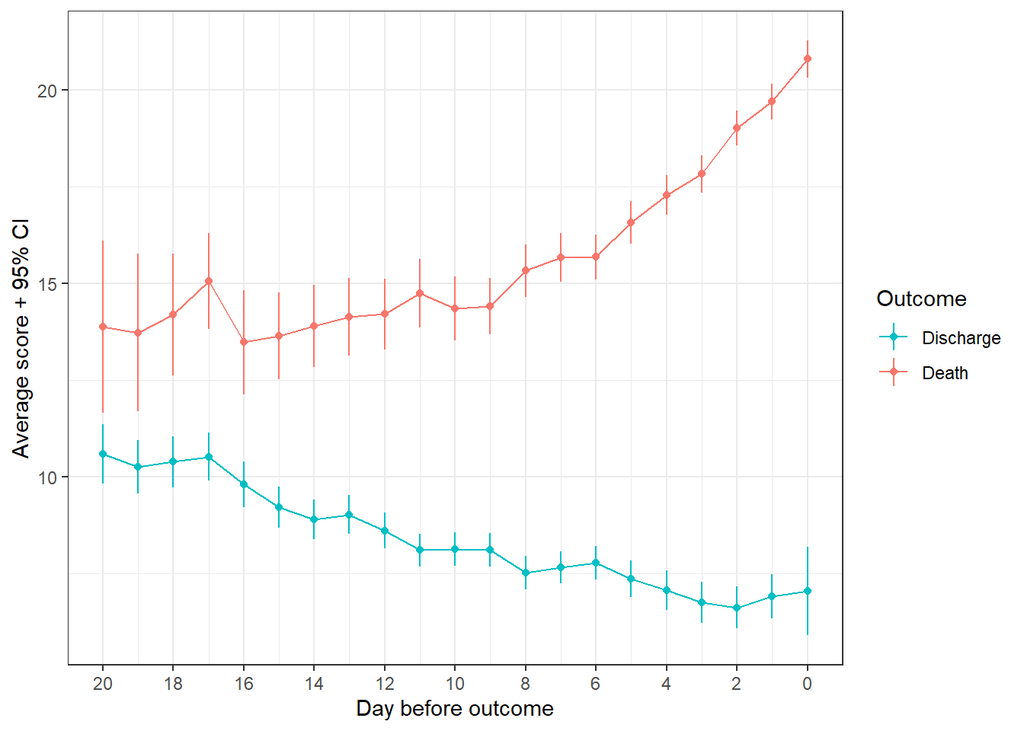

```r
score_9 %>%
    group_by(Outcome, DaysBfOutcome) %>%
    summarise(M = mean(score),
              LCL = t.test(score)$conf.int[1],
              UCL = t.test(score)$conf.int[2]) %>%
  ggplot(aes(x = DaysBfOutcome, y = M, colour = Outcome)) +
  geom_linerange(aes(ymin = LCL, ymax = UCL)) +
  geom_line() +
  geom_point() +
  theme_bw() +
  ylab("Average score + 95% CI") +
  xlab("Day before outcome") +
  scale_color_manual(labels=c("Discharge","Death"), values = c("#00BFC4", "#F8766B")) +
  scale_x_reverse(breaks = seq(20, 0, -2))
```

Мы видим, что по мере приближения к исходу различия в показателе score между выписавшимися и умершими пациентами нарастают.

## Интерпретация показателя

Оценим, как именно рост показателя score связан с шансом развития летального исхода на разных сроках

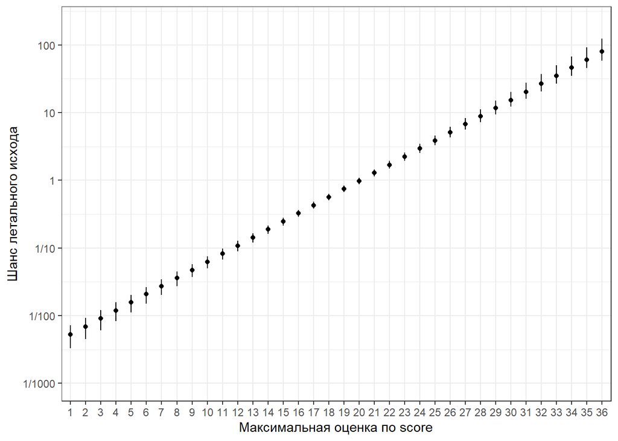

```r
# Сначала у каждого пациента считается максимальное значение score

score_9_max <- score_9 %>%
    group_by(id, Outcome) %>%
    summarise(score = max(score, na.rm = TRUE))

# Строится модель логистической регрессии для данного значения

glm_outcome <- glm(Outcome ~ score, family=binomial, data = score_9_max)

# Построим таблицу ожидаемых вероятностей летального исхода с помощью модели

score <- seq(1, 36, by = 1)
scores <- as.data.frame(score)
predictions <- predict.glm(glm_outcome, scores, type="response", se.fit = TRUE)

# Рассчитаем ДИ

scores$outcome_pr <- predictions$fit
ci <- 1.96 * predictions$se.fit
scores$ci_low_pr <- predictions$fit - ci
scores$ci_up_pr <- predictions$fit + ci

# Рассчитаем шансы летального исхода и ДИ для них (odd = death probability/discharge probability)

scores$odd <- round(scores$outcome_pr/(1- scores$outcome_pr), 5)
scores$ci_low_odd <- round(scores$ci_low_pr/(1- scores$ci_low_pr), 5)
scores$ci_up_odd <- round(scores$ci_up_pr/(1-scores$ci_up_pr), 5)
scores$score <- as.factor(scores$score)

# Построим график зависимости шанса летального исхода от значений score

ggplot(scores, aes(x=score, y=odd)) +
    geom_linerange(aes(ymin=ci_low_odd, ymax=ci_up_odd)) +
    geom_line() +
    geom_point() +
    theme_bw() +
    scale_y_log10(limits = c(0.001, 200),
                  breaks=c(0.001,0.01,0.1,1,10,100),
                  labels = c("1/1000", "1/100", "1/10", "1","10","100")) +
    labs(x = "Максимальная оценка по score",
         y = "Шанс летального исхода")
```

Построим таблицу для оценки градаций риска.

```r
thresholds <- c("<4", "[4, 8)", "[8, 14)", "[14, 20)", ">=20")
odds <- c("< 1:100","1:100 - 1:25", "1:25 -  1:5", "1:5 - 1:1", ">1:1")
risk_grade <- c("Very Low", "Low", "Average", "High", "Very High")
data <- data.frame(thresholds, odds, risk_grade)
colnames(data) <- c("Score range", "Expected death/discharge odds", "Risk grade")
data %>% flextable(cwidth = 1.5) %>%
  theme_box() %>%
  align(align = "center", part = "all")
```

| Score range | Expected death/discharge odds | Risk grade |
| --- | --- | --- |
| <4 | < 1:100 | Very Low |
| [4, 8) | 1:100 - 1:25 | Low |
| [8, 14) | 1:25 - 1:5 | Average |
| [14, 20) | 1:5 - 1:1 | High |
| >=20 | >1:1 | Very High |

Построим график для оценки шансов летального исхода по аналогии с графиков в референтной статье.

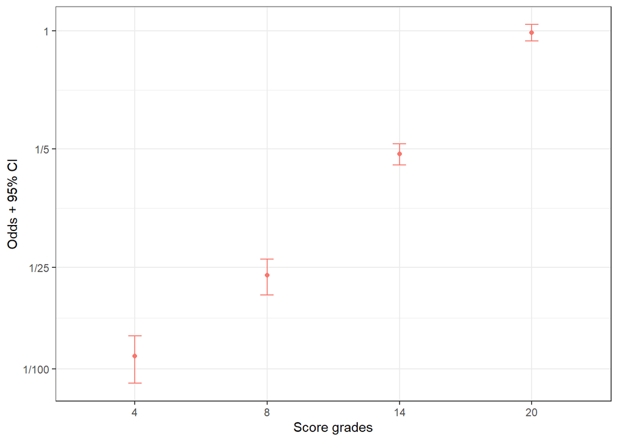

```r
data <- filter(scores, score %in% c(4,8,14,20))

ggplot(data, aes(x=score, y=odd, color = "")) +
    geom_errorbar(aes(ymin=ci_low_odd, ymax=ci_up_odd), width=.1) +
    geom_line() +
    geom_point() +
    theme_bw() +
    scale_y_log10(breaks = c(0.01,0.04,0.2,1), labels = c("1/100","1/25","1/5","1")) +
    ylab("Odds + 95% CI") +
    xlab("Score grades") +
    theme(legend.position = "none")
```

## Анализ времени до наступления исхода

```r
# Считаем максимальный день до исхода, когда первый раз сработал score для каждого пациента.

PrRange <- data.frame(score = NA, M = NA, LCL = NA, UCL = NA) %>%
  mutate_all(~ as.numeric(.x))

for (i in 1:length(unique(score_9$score))) {
  score_9 %>%
    filter(Outcome == 1, score >= unique(score_9$score)[i]) %>%
    mutate(DaysBfOutcome = as.character(DaysBfOutcome) %>% as.numeric()) %>%
    group_by(id) %>%
    summarise(first_trigger = max(DaysBfOutcome)) %>%
    ungroup() %>%
    summarise(M = mean(first_trigger),
              LCL = t.test(first_trigger)$conf.int[1],
              UCL = t.test(first_trigger)$conf.int[2]) -> stats
  PrRange[i, "score"] <- unique(score_9$score)[i]
  PrRange[i, "M"] <- stats$M[1]
  PrRange[i, "LCL"] <- stats$LCL[1]
  PrRange[i, "UCL"] <- stats$UCL[1]
}

PrRange
```

```
##    score        M       LCL      UCL
## 1      0 9.261062 8.9224447 9.599679
## 2     10 8.177072 7.8326128 8.521530
## 3      4 9.010000 8.6711473 9.348853
## 4      6 8.842984 8.5025884 9.183380
## 5      9 8.423251 8.0800239 8.766477
## 6     13 7.656909 7.3096659 8.004151
## 7     17 6.741445 6.3829963 7.099893
## 8     11 8.010321 7.6652381 8.355404
## 9      7 8.761161 8.4221217 9.100200
## 10     8 8.577354 8.2368576 8.917851
## 11    15 7.144753 6.7940988 7.495407
## 12    16 7.074257 6.7189084 7.429606
## 13    22 5.155822 4.7839043 5.527740
## 14    18 6.292490 5.9380286 6.646952
```

[output cut: 18 more lines]

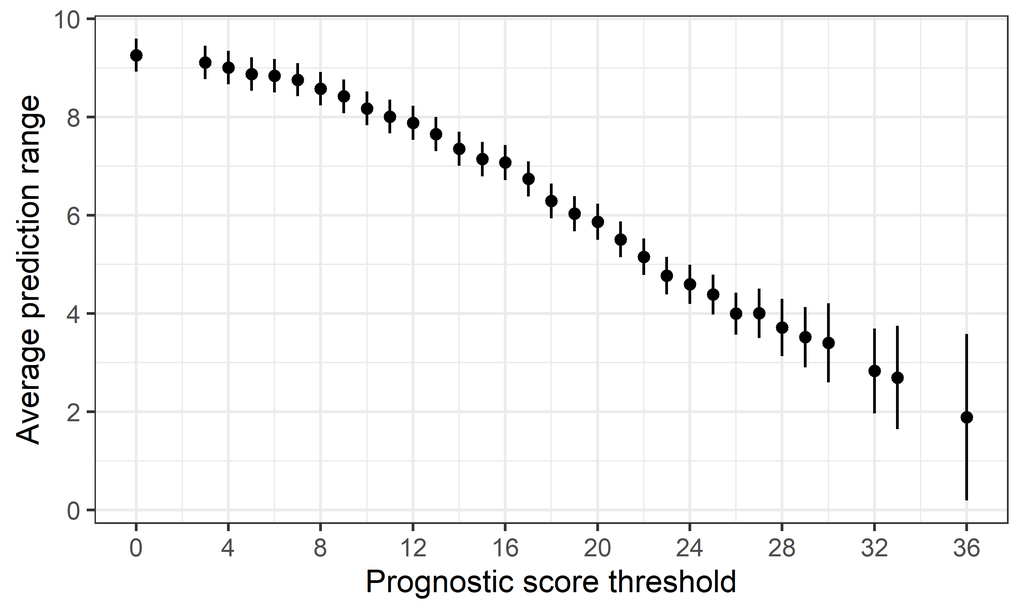

```r
PrRange %>% ggplot(aes(x = score)) +
  geom_point(aes(y = M)) +
  geom_linerange(aes(ymin = LCL, ymax = UCL)) +
  labs(x = "Prognostic score threshold",
       y = "Average prediction range") +
  scale_x_continuous(breaks = seq(0, 36, by = 4)) +
  scale_y_continuous(breaks = seq(0, 10, by = 2)) +
  theme_bw()
```

## Анализ чувствительности и специфичности шкалы

```r
# Строим таблицу с частотами умерших и выживших пациентов на каждом уровне максимального score

score_9_max %>%
  group_by(score) %>%
  summarise(n_dead = sum(Outcome == 1),
            N = sum(!is.na(Outcome))) %>%
  mutate(n_surv = N - n_dead,
         freq_dead = (100 * n_dead / N) %>% round(1),
         freq_surv = (100 * n_surv / N) %>% round(1),
         .before = N) -> SurvDeadRate

SurvDeadRate %>% head() %>% flextable() %>% theme_box()
```

| score | n_dead | n_surv | freq_dead | freq_surv | N |
| --- | --- | --- | --- | --- | --- |
| 0 | 1 | 415 | 0.2 | 99.8 | 416 |
| 3 | 3 | 180 | 1.6 | 98.4 | 183 |
| 4 | 2 | 222 | 0.9 | 99.1 | 224 |
| 5 | 0 | 16 | 0.0 | 100.0 | 16 |
| 6 | 2 | 73 | 2.7 | 97.3 | 75 |
| 7 | 4 | 108 | 3.6 | 96.4 | 112 |

Построим график, как менялась доля умерших пациентов в зависимости от уровня score.

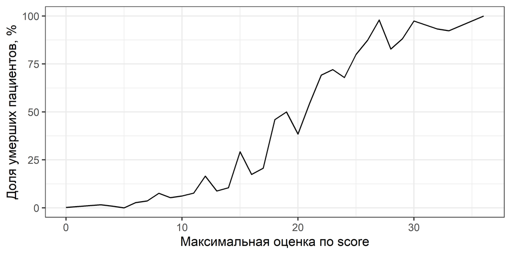

```r
ggplot(SurvDeadRate, aes(x = score)) +
  geom_line(aes(y = freq_dead)) +
  theme_bw() +
  labs(y = "Доля умерших пациентов, %",
       x = "Максимальная оценка по score")
```

```r
# С помощью цикла рассчитываем значения TP, FP, TN и FN для максимальных значений score

TP <- c()
TN <- c()
FP <- c()
FN <- c()

for (i in 1:length(SurvDeadRate$score)) {
  TP[i] <- SurvDeadRate %>% filter(score > score[i]) %>% pull(n_dead) %>% sum()
  FP[i] <- SurvDeadRate %>% filter(score > score[i]) %>% pull(n_surv) %>% sum()
  TN[i] <- SurvDeadRate %>% filter(score <= score[i]) %>% pull(n_surv) %>% sum()
  FN[i] <- SurvDeadRate %>% filter(score <= score[i]) %>% pull(n_dead) %>% sum()
}

Sens_DB <- tibble(score = SurvDeadRate$score, TP, FP, TN, FN) %>%
  mutate(Sensitivity = 100 * TP / (TP + FN),
         Specificity = 100 * TN / (TN + FP)) %>%
  rowwise() %>%
  mutate(LCL_Se = 100*binom.test(c(TP, FN))$conf.int[1],
         UCL_Se = 100*binom.test(c(TP, FN))$conf.int[2],
         LCL_Sp = 100*binom.test(c(TN, FP))$conf.int[1],
         UCL_Sp = 100*binom.test(c(TN, FP))$conf.int[2],)

Sens_DB %>% head() %>% flextable() %>% theme_box()
```

| score | TP | FP | TN | FN | Sensitivity | Specificity | LCL_Se | UCL_Se | LCL_Sp | UCL_Sp |
| --- | --- | --- | --- | --- | --- | --- | --- | --- | --- | --- |
| 0 | 903 | 1,843 | 415 | 1 | 99.88938 | 18.37910 | 99.38522 | 99.99720 | 16.80125 | 20.03944 |
| 3 | 900 | 1,663 | 595 | 4 | 99.55752 | 26.35075 | 98.87099 | 99.87931 | 24.54319 | 28.21988 |
| 4 | 898 | 1,441 | 817 | 6 | 99.33628 | 36.18246 | 98.56100 | 99.75605 | 34.19732 | 38.20353 |
| 5 | 898 | 1,425 | 833 | 6 | 99.33628 | 36.89105 | 98.56100 | 99.75605 | 34.89682 | 38.91936 |
| 6 | 896 | 1,352 | 906 | 8 | 99.11504 | 40.12400 | 98.26377 | 99.61719 | 38.09409 | 42.17958 |
| 7 | 892 | 1,244 | 1,014 | 12 | 98.67257 | 44.90700 | 97.69273 | 99.31227 | 42.84100 | 46.98623 |

Построим графики для чувствительности и специфичности выявления летальных случаев в зависимости от различных пороговых значений максимального score, наблюдавшегося у пациентов.

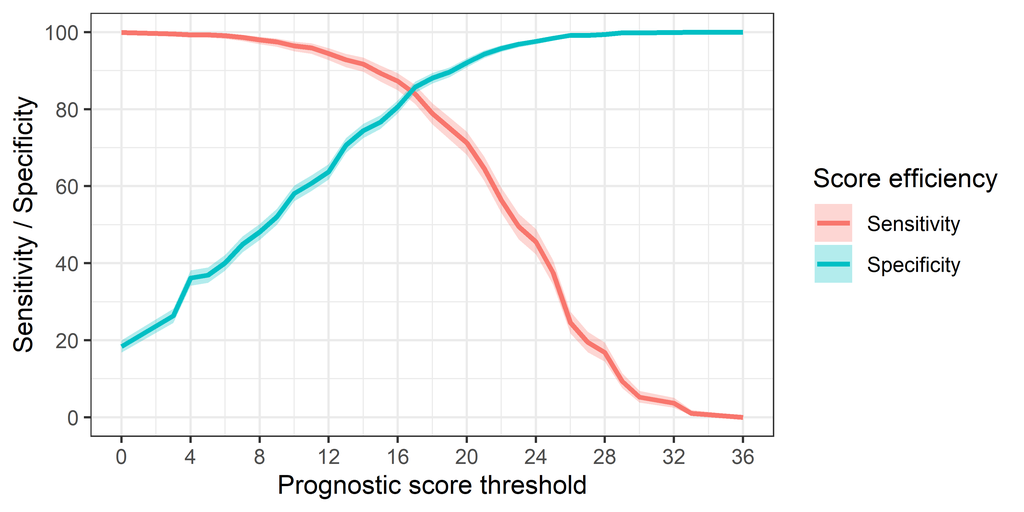

```r
Sens_DB_Se <- Sens_DB %>%
  select(score, value = Sensitivity, LCL = LCL_Se, UCL = UCL_Se) %>%
  mutate(`Score efficiency` = "Sensitivity")

Sens_DB_Sp <- Sens_DB %>%
  select(score, value = Specificity, LCL = LCL_Sp, UCL = UCL_Sp) %>%
  mutate(`Score efficiency` = "Specificity")

rbind(Sens_DB_Se, Sens_DB_Sp) %>%
  ggplot(aes(x = score, color = `Score efficiency`, fill = `Score efficiency`)) +
    geom_ribbon(aes(ymin = LCL, ymax = UCL), alpha = 0.3, color = NA) +
    geom_line(aes(y = value), size = 1) +
    labs(x = "Prognostic score threshold",
         y = "Sensitivity / Specificity") +
    scale_y_continuous(breaks = seq(0, 100, by = 20)) +
    scale_x_continuous(breaks = seq(0, 36, by = 4)) +
    theme_bw()
```